# M5RR - Week 2 Assignment

Tnargz

5/27/2020

1. Loading and preprocessing the data. Show any code that is needed to load the data (i.e. read.csv()) and process/transform the data (if necessary) into a format suitable for your analysis.

```r
library(lubridate)
library(RCurl)
library(tidyverse)
library(ggplot2)
library(dplyr)
library(magrittr)
library(readr)
library(gridExtra)
library(knitr)
```

```r
FileUrl <- "https://d396qusza40orc.cloudfront.net/repdata%2Fdata%2Factivity.zip"
ZipFile <- "./M5RR-Week2-Assignment/Data.zip"
FileDir <- "./M5RR-Week2-Assignment"
Path <- "./M5RR-Week2-Assignment/Data"
if (!file.exists(FileDir)){
  dir.create(FileDir)
}
download.file(FileUrl, file.path(ZipFile))
unzip(ZipFile, exdir = Path)
Data <- file.path(Path, "activity.csv")
activity <- read.csv(Data)
head(activity, 5)
```

```
##   steps       date interval
## 1    NA 2012-10-01        0
## 2    NA 2012-10-01        5
## 3    NA 2012-10-01       10
## 4    NA 2012-10-01       15
## 5    NA 2012-10-01       20
```

2. total number of steps taken per day

```r
TotalStepsPerDay <- activity %>%
  group_by(date) %>%
  summarise(stepsperday = sum(steps))
head(TotalStepsPerDay, 5)
```

```
## # A tibble: 5 x 2
##   date       stepsperday
##   <chr>            <int>
## 1 2012-10-01          NA
## 2 2012-10-02         126
## 3 2012-10-03       11352
## 4 2012-10-04       12116
## 5 2012-10-05       13294
```

2.1. What is mean total number of steps taken per day?

```r
TotalStepsPerDay_Mean <- TotalStepsPerDay %>%
  summarise(mean = mean(stepsperday, na.rm = TRUE))
TotalStepsPerDay_Mean
```

```
## # A tibble: 1 x 1
##     mean
##    <dbl>
## 1 10766.
```

2.2. Make a histogram of the total number of steps taken each day.

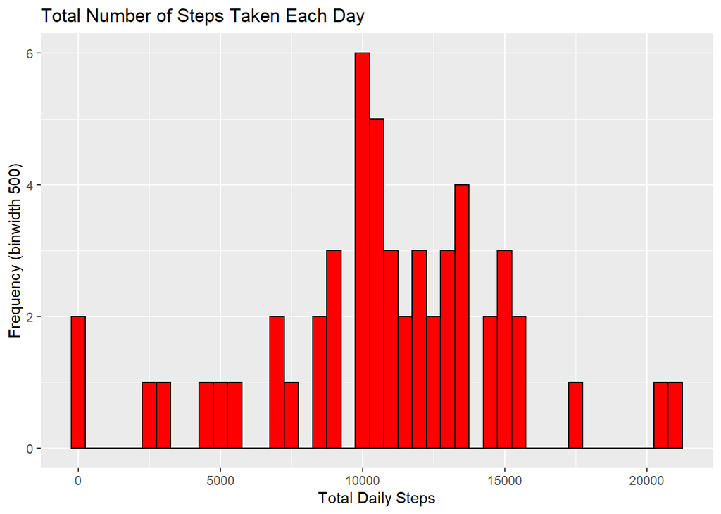

```r
ggplot(data = TotalStepsPerDay, aes(x = stepsperday), rm.na = TRUE) +
  geom_histogram(binwidth = 500, col = "black", fill = "red") +
  labs(x = "Total Daily Steps", y = "Frequency (binwidth 500)",
       title = "Total Number of Steps Taken Each Day")
```

2.3. Calculate and report the mean and median of the total number of steps taken per day

```r
TotalStepsPerDay_MeanMedian <- TotalStepsPerDay %>%
  summarise(mean = mean(stepsperday, na.rm = TRUE),
            median = median(stepsperday, na.rm = TRUE))
TotalStepsPerDay_MeanMedian
```

```
## # A tibble: 1 x 2
##     mean median
##    <dbl>  <int>
## 1 10766.  10765
```

3. What is the average daily activity pattern?

```r
activitypattern <- activity %>%
  group_by(interval) %>%
  summarise(mean_steps = mean(steps, na.rm = TRUE))
summary(activitypattern)
```

```
##     interval        mean_steps
##  Min.   :   0.0   Min.   :  0.000
##  1st Qu.: 588.8   1st Qu.:  2.486
##  Median :1177.5   Median : 34.113
##  Mean   :1177.5   Mean   : 37.383
##  3rd Qu.:1766.2   3rd Qu.: 52.835
##  Max.   :2355.0   Max.   :206.170
```

3.1. Make a time series plot (i.e. type = “l”) of the 5-minute interval (x-axis) and the average number of steps taken,,averaged across all days (y-axis).

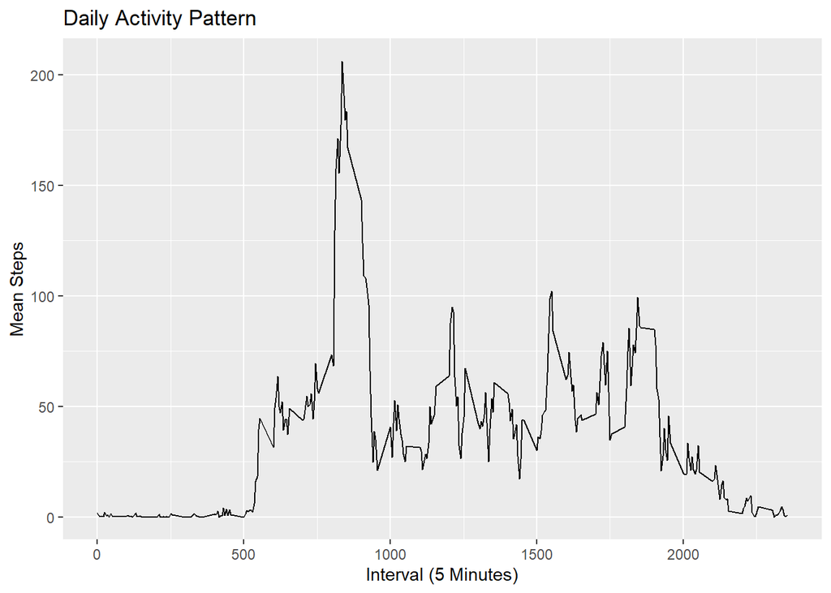

```r
ggplot(data = activitypattern, aes(x = interval, y = mean_steps), rm.na = TRUE) +
  geom_line() +
  labs(x = "Interval (5 Minutes)", y = "Mean Steps",
       title = "Daily Activity Pattern")
```

3.2. Which 5-minute interval, on average across all the days in the dataset, contains the maximum number of steps?

```r
MaxSteps <- activitypattern[order(-activitypattern$mean_steps),]
MaxSteps
```

```
## # A tibble: 288 x 2
##    interval mean_steps
##       <int>      <dbl>
##  1      835       206.
##  2      840       196.
##  3      850       183.
##  4      845       180.
##  5      830       177.
##  6      820       171.
##  7      855       167.
##  8      815       158.
##  9      825       155.
## 10      900       143.
## # ... with 278 more rows
```

4. Calculate and report the total number of missing values in the dataset (i.e. the total number of rows with NAs).

```r
summary(activity)
```

```
##      steps            date              interval
##  Min.   :  0.00   Length:17568       Min.   :   0.0
##  1st Qu.:  0.00   Class :character   1st Qu.: 588.8
##  Median :  0.00   Mode  :character   Median :1177.5
##  Mean   : 37.38                      Mean   :1177.5
##  3rd Qu.: 12.00                      3rd Qu.:1766.2
##  Max.   :806.00                      Max.   :2355.0
##  NA's   :2304
```

4.1. Devise a strategy for filling in all of the missing values in the dataset. The strategy does not need to be sophisticated. For example, you could use the mean/median for that day, or the mean for that 5-minute interval, etc.

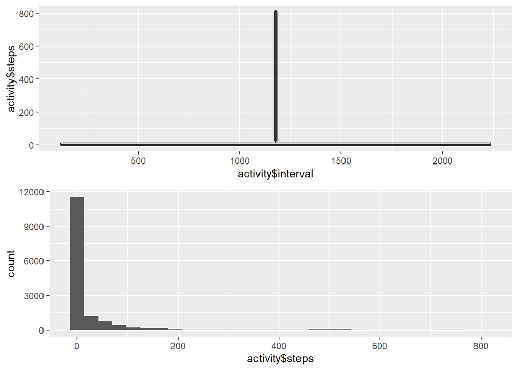

```r
plot1 <- ggplot(activity, aes(activity$interval, activity$steps), rm.na = TRUE) +
  geom_boxplot()
plot2 <- ggplot(activity, aes(activity$steps), rm.na = TRUE) +
  geom_histogram()
grid.arrange(plot1, plot2, nrow = 2)
```

```r
summary(activity)
```

```
##      steps            date              interval
##  Min.   :  0.00   Length:17568       Min.   :   0.0
##  1st Qu.:  0.00   Class :character   1st Qu.: 588.8
##  Median :  0.00   Mode  :character   Median :1177.5
##  Mean   : 37.38                      Mean   :1177.5
##  3rd Qu.: 12.00                      3rd Qu.:1766.2
##  Max.   :806.00                      Max.   :2355.0
##  NA's   :2304
```

The median will be used due to the right skew nature of the data set.

4.2. Create a new dataset that is equal to the original dataset but with the missing data filled in.

```r
Na_to_Median <- function(x) replace(x, is.na(x), median(x, na.rm = TRUE))
activity2 <- activity %>% group_by(interval) %>% mutate(steps = Na_to_Median(steps))
summary(activity)
```

```
##      steps            date              interval
##  Min.   :  0.00   Length:17568       Min.   :   0.0
##  1st Qu.:  0.00   Class :character   1st Qu.: 588.8
##  Median :  0.00   Mode  :character   Median :1177.5
##  Mean   : 37.38                      Mean   :1177.5
##  3rd Qu.: 12.00                      3rd Qu.:1766.2
##  Max.   :806.00                      Max.   :2355.0
##  NA's   :2304
```

```r
summary(activity2)
```

```
##      steps         date              interval
##  Min.   :  0   Length:17568       Min.   :   0.0
##  1st Qu.:  0   Class :character   1st Qu.: 588.8
##  Median :  0   Mode  :character   Median :1177.5
##  Mean   : 33                      Mean   :1177.5
##  3rd Qu.:  8                      3rd Qu.:1766.2
##  Max.   :806                      Max.   :2355.0
```

[figure not shown]

```r
ggplot(data = activity2, aes(x = activity2$steps)) +
  geom_histogram(binwidth = 30, col = "black", fill = "yellow") +
  labs(x = "Total Daily Steps", y = "Frequency (binwidth 30)",
       title = "Total Number of Steps Taken Each Day")
```

```r
summary(activity)
```

```
##      steps            date              interval
##  Min.   :  0.00   Length:17568       Min.   :   0.0
##  1st Qu.:  0.00   Class :character   1st Qu.: 588.8
##  Median :  0.00   Mode  :character   Median :1177.5
##  Mean   : 37.38                      Mean   :1177.5
##  3rd Qu.: 12.00                      3rd Qu.:1766.2
##  Max.   :806.00                      Max.   :2355.0
##  NA's   :2304
```

```r
summary(activity2)
```

```
##      steps         date              interval
##  Min.   :  0   Length:17568       Min.   :   0.0
##  1st Qu.:  0   Class :character   1st Qu.: 588.8
##  Median :  0   Mode  :character   Median :1177.5
##  Mean   : 33                      Mean   :1177.5
##  3rd Qu.:  8                      3rd Qu.:1766.2
##  Max.   :806                      Max.   :2355.0
```

5. Are there differences in activity patterns between weekdays and weekends? For this part the weekdays() function may be of some help here. Use the dataset with the filled-in missing values for this part.

5.1 Create a new factor variable in the dataset with two levels – “weekday” and “weekend” indicating whether a given date is a weekday or weekend day.

```r
day_of_the_week <- wday(activity2$date)
f <- function(i) {
  day_to_category <- c('weekend',
                       'weekday',
                       'weekday',
                       'weekday',
                       'weekday',
                       'weekday',
                       'weekend')
  return (day_to_category[i])
}

activity2$time_of_week <- sapply(day_of_the_week, f)
str(activity2)
```

[output not shown]

[output cut: 54 more lines]

[output not shown]

```r
head(activity2, 5)
```

```
## # A tibble: 5 x 4
## # Groups:   interval [5]
##   steps date       interval time_of_week
##   <int> <chr>         <int> <chr>
## 1     0 2012-10-01        0 weekday
## 2     0 2012-10-01        5 weekday
## 3     0 2012-10-01       10 weekday
## 4     0 2012-10-01       15 weekday
## 5     0 2012-10-01       20 weekday
```

```r
stepsperday_weekday <- activity2 %>%
  filter(time_of_week == 'weekday') %>%
  group_by(interval) %>%
  summarise(steps = mean(steps, na.rm = TRUE))
summary(stepsperday_weekday)
```

```
##     interval          steps
##  Min.   :   0.0   Min.   :  0.000
##  1st Qu.: 588.8   1st Qu.:  1.922
##  Median :1177.5   Median : 20.778
##  Mean   :1177.5   Mean   : 31.154
##  3rd Qu.:1766.2   3rd Qu.: 45.928
##  Max.   :2355.0   Max.   :205.422
```

```r
stepsperday_weekend <- activity2 %>%
  filter(time_of_week == 'weekend') %>%
  group_by(interval) %>%
  summarise(steps = mean(steps, na.rm = TRUE))
summary(stepsperday_weekend)
```

```
##     interval          steps
##  Min.   :   0.0   Min.   :  0.0000
##  1st Qu.: 588.8   1st Qu.:  0.9688
##  Median :1177.5   Median : 28.1562
##  Mean   :1177.5   Mean   : 38.1888
##  3rd Qu.:1766.2   3rd Qu.: 67.9375
##  Max.   :2355.0   Max.   :155.0000
```

[figure not shown]

```r
plot3 <- ggplot(data = stepsperday_weekday, aes(x = steps)) +
  geom_histogram(binwidth = 10, col = "black", fill = "white") +
  labs(x = "Total Daily Steps", y = "Frequency (binwidth 10)",
       title = "Total Steps Taken on Weekday")
plot4 <- ggplot(data = stepsperday_weekend, aes(x = steps)) +
  geom_histogram(binwidth = 10, col = "black", fill = "white") +
  labs(x = "Total Daily Steps", y = "Frequency (binwidth 10)",
       title = "Total Steps Taken on Weekend")
grid.arrange(plot3, plot4, nrow = 2)
```